# STA-141A Final Project

Zohd Khan

2023-06-12

**Loading Test Sets for Prediction Model**

```r
session612 <- list()

for (i in 1:2) {
  session612[[i]] <- readRDS(paste("C:/Users/Zohd/Desktop/STA-141A/test", i, '.rds', sep=''))
  print(session612[[i]]$mouse_name)
  print(session612[[i]]$date_exp)
}
```

```
## [1] "Cori"
## [1] "2016-12-14"
## [1] "Lederberg"
## [1] "2017-12-11"
```

**Loading Data across 18 relevant sessions**

```r
session <- list()

for (i in 1:18) {
  session[[i]] <- readRDS(paste("C:/Users/Zohd/Desktop/STA-141A/Data/sessions/session", i, '.rds', sep=''))
  print(session[[i]]$mouse_name)
  print(session[[i]]$date_exp)
}
```

```
## [1] "Cori"
## [1] "2016-12-14"
## [1] "Cori"
## [1] "2016-12-17"
## [1] "Cori"
## [1] "2016-12-18"
## [1] "Forssmann"
## [1] "2017-11-01"
## [1] "Forssmann"
## [1] "2017-11-02"
## [1] "Forssmann"
## [1] "2017-11-04"
## [1] "Forssmann"
## [1] "2017-11-05"
## [1] "Hench"
```

[output cut: 21 more lines]

```r
#sink("C:/Users/Zohd/Desktop/STA-141A/Data/sessions/session",append = TRUE, split = TRUE)
```

**Abstract**

We introduce the background of relevant data and explain the objective of our report. We explore our data, particularly by using plots to investigate how the data changes across sessions. We then integrate our data through k-means clustering and other techniques to ensure an effective prediction model in next part. We then build the prediction model using the glm() function to predict randomly chosen 100 randomly chosen trials from sessions 1 and 18 of our data. We conclude by discussing our findings from the report and discuss model’s effectiveness in predicting feedback types.

**Introduction**

The brain, with its complex network of neurons, is the source of our cognitive abilities and behavior. Understanding how neural activity translates into behavior and cognition is a question of profound scientific interest.

This report aims to explore neural activity data of mice captured across 18 experimental sessions and develop a predictive model to forecast feedback types based on this data. The relevant dataset, which was obtained from a 2019 experiment from Steinmetz and company, contains recorded neural activities or ‘spikes’ of different neurons over many trials for 38 total sessions with 10 different mice. As touched on before, the report covers the first 18 sessions with data on only 4 mice and spike trains of neurons from the onset of the stimuli to 0.4 seconds post-onset being included.

**Exploratory Analysis**

**(i) Description of data across sessions**

The data covered in this report, obtained by the 2019 experiment by Steinmetz and company, is stored in 18 RDS files across 18 sessions with 8 variables in each session. Following is the information on each variable:

1.contrast_left: Contrast of the stimulus presented in the left screen, ranging from values {0,0.25,0.5,1}. This is stored in a matrix.

2.contrast_right: Contrast of the stimulus presented in the right screen, ranging from values {0,0.25,0.5,1}. This is stored in a matrix.

3.feedback_type: Represents the result of each trial, which is type of the feedback given. A 1 is issued for success and -1 is issued for failure. Success and failure is determined by whether the mouse makes the correct decision. This is stored in a matrix.

4.mouse_name: name of mouse. This is stored as a character string value.

5.date_exp: date of experiment. This is stored as a character string value.

6.brain_area: area of the brain where each neuron lives. This is stored in a character vector.

7.spks: numbers of spikes of neurons in the visual cortex in time bins defined in time. This is stored in a list containing many elements, with each element being a matrix corresponding to the number of spikes recorded for each trial.

8.time: centers of the time bins for spks. This is stored in a list with the same amount of elements as spks, although the elements in the list for time are numeric vectors representing the centers of the time bins.

**(ii) Exploring neural activities across trials in all sessions**

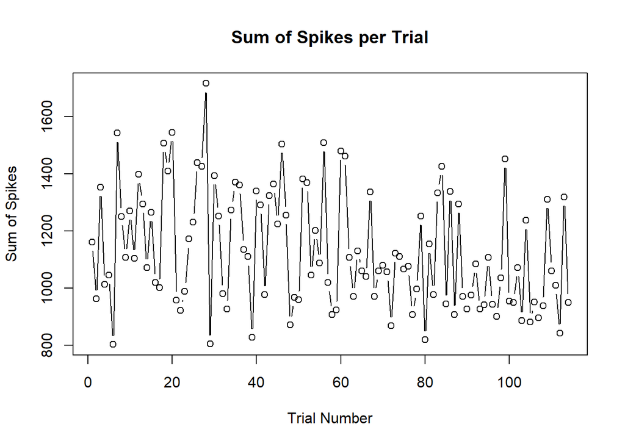

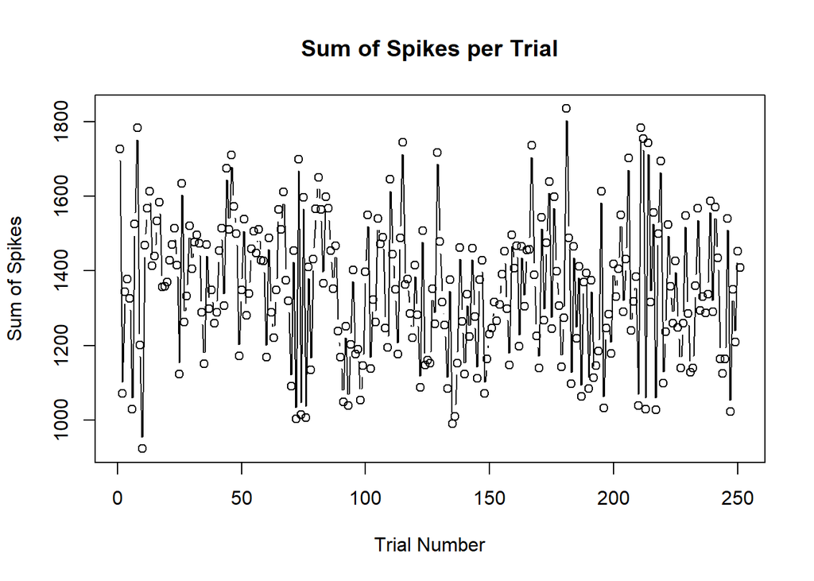

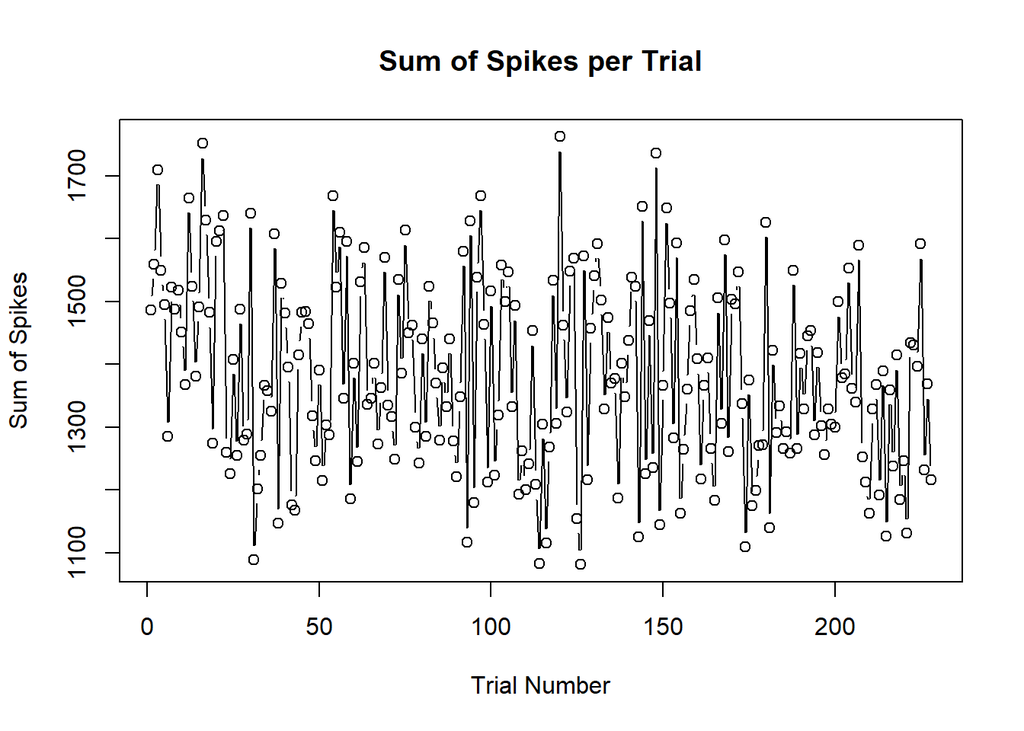

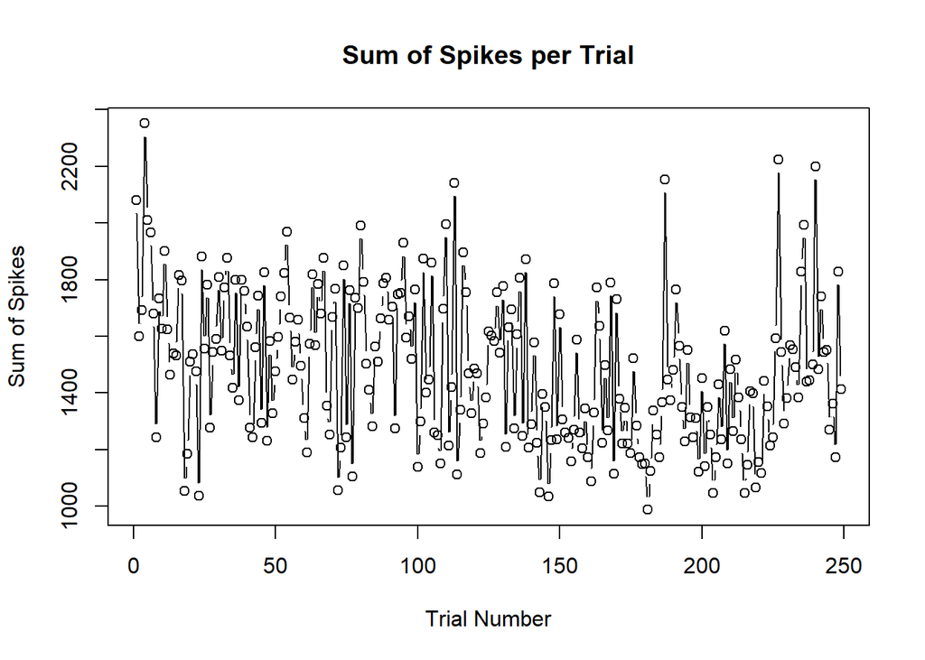

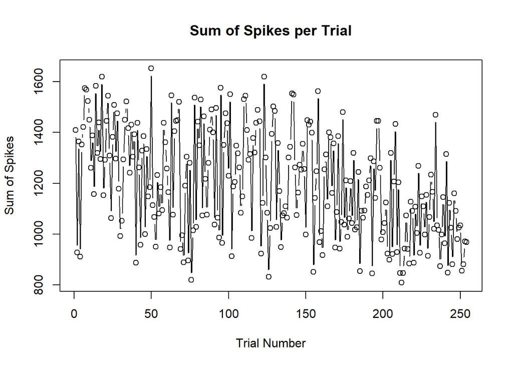

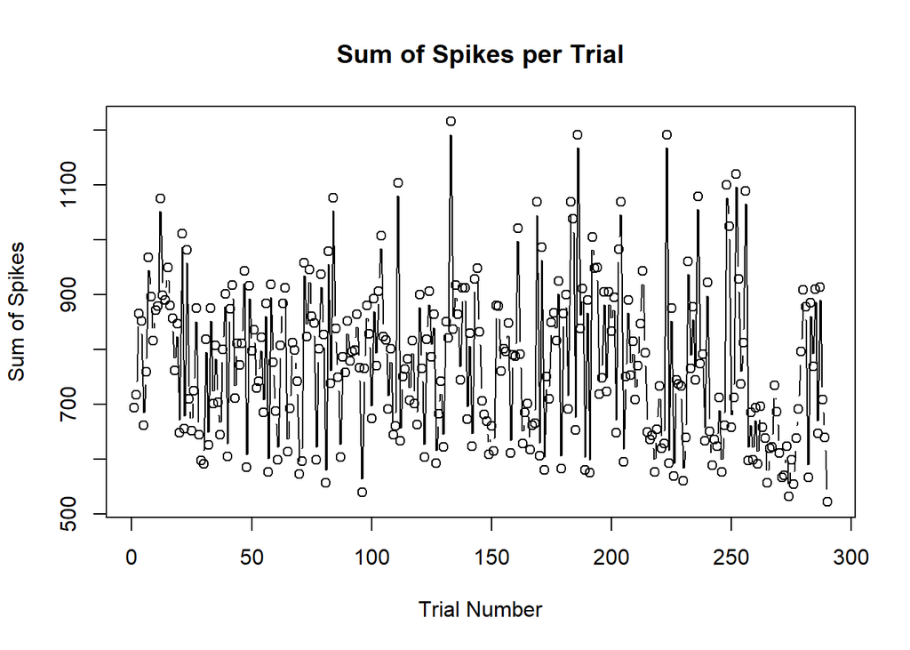

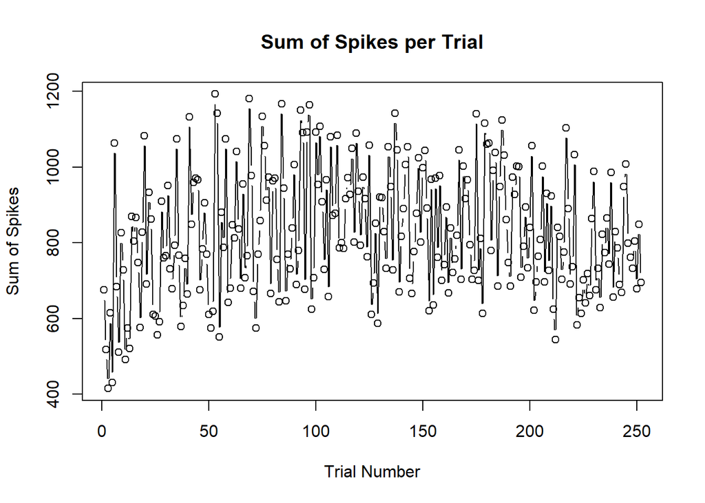

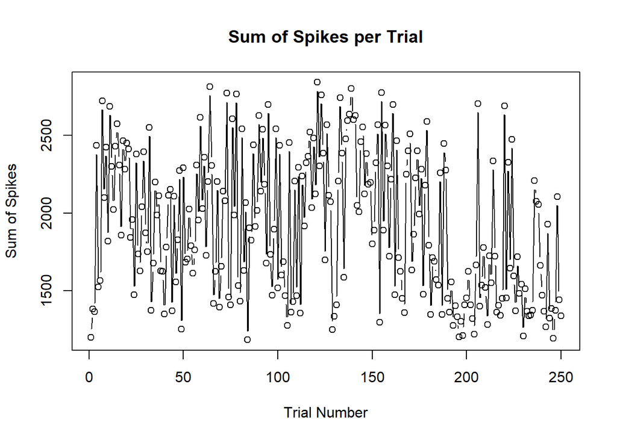

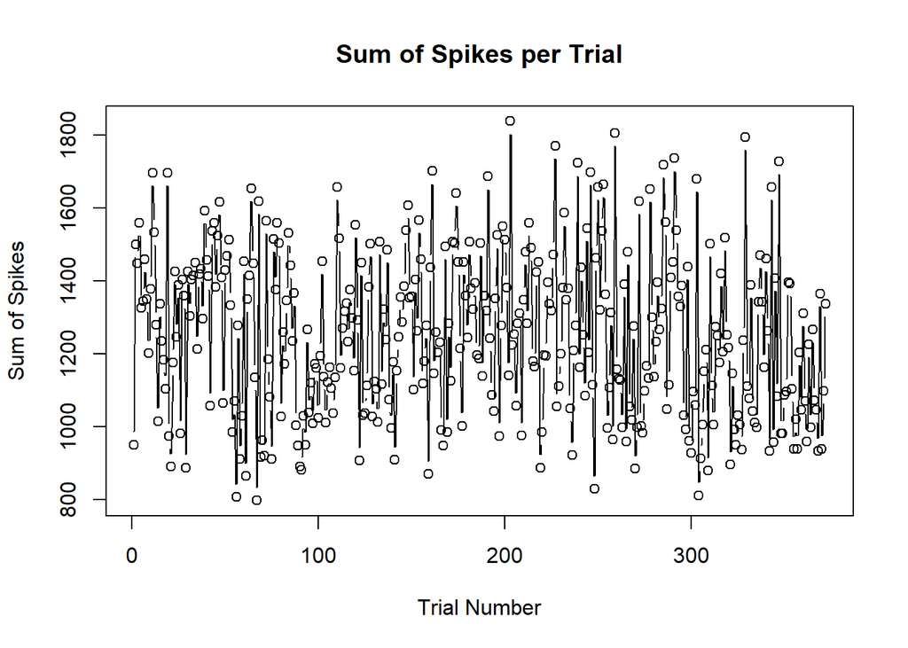

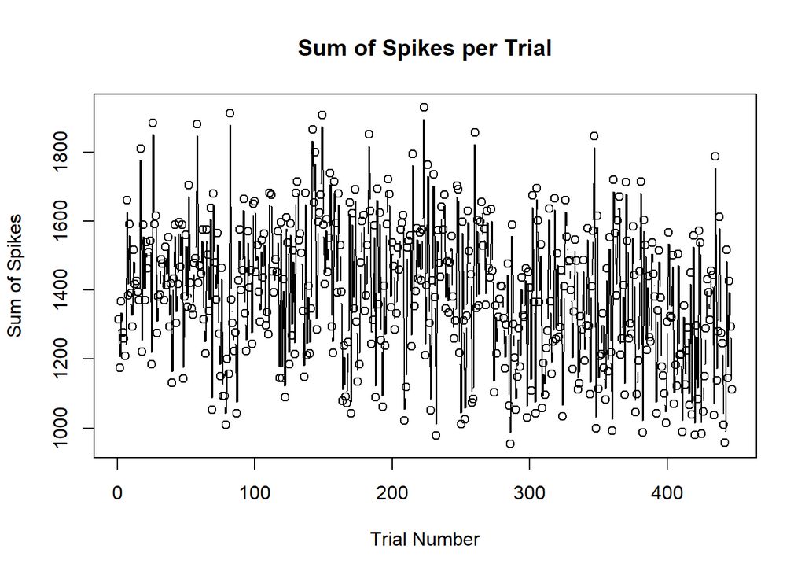

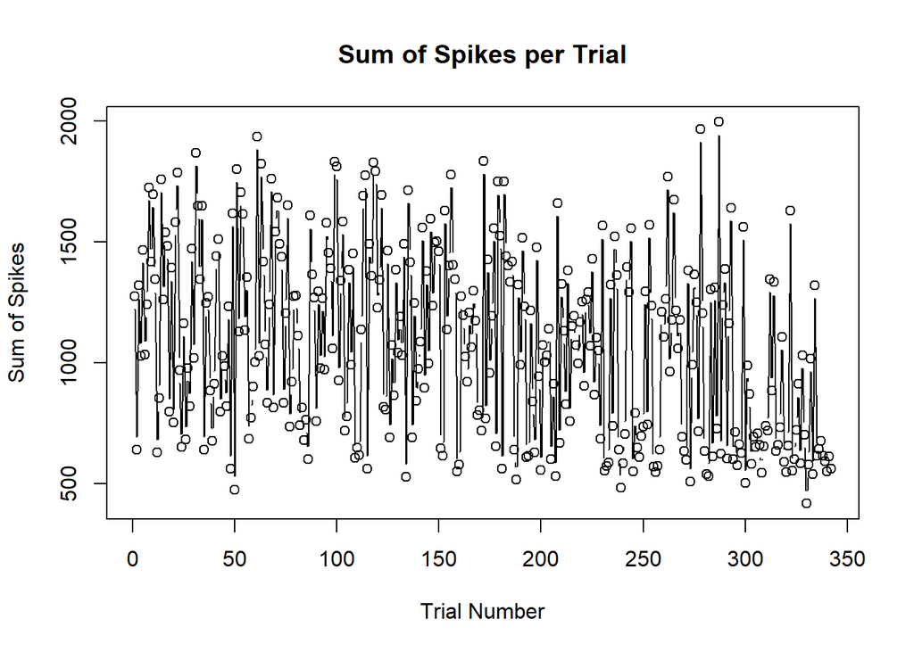

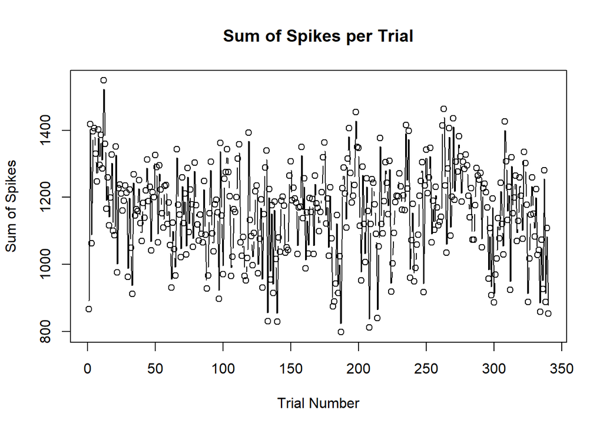

[6 more figures not shown]

```r
for (ssn in 1:length(session)) {

# Initialize an empty vector to store the sums
sum_spks <- numeric(length(session[[ssn]]$spks))

# Compute and store the sum for each trial
for (trial in 1:length(session[[ssn]]$spks)) {

  # Compute the sum of spikes for this trial
  sum_spks[trial] <- sum(session[[ssn]]$spks[[trial]])

  #print(trial)

}

# Create a sequence of trials
trials <- 1:length(sum_spks)

# Create a plot
plot(trials, sum_spks, type = 'b', main = "Sum of Spikes per Trial",
     xlab = "Trial Number", ylab = "Sum of Spikes")

}
```

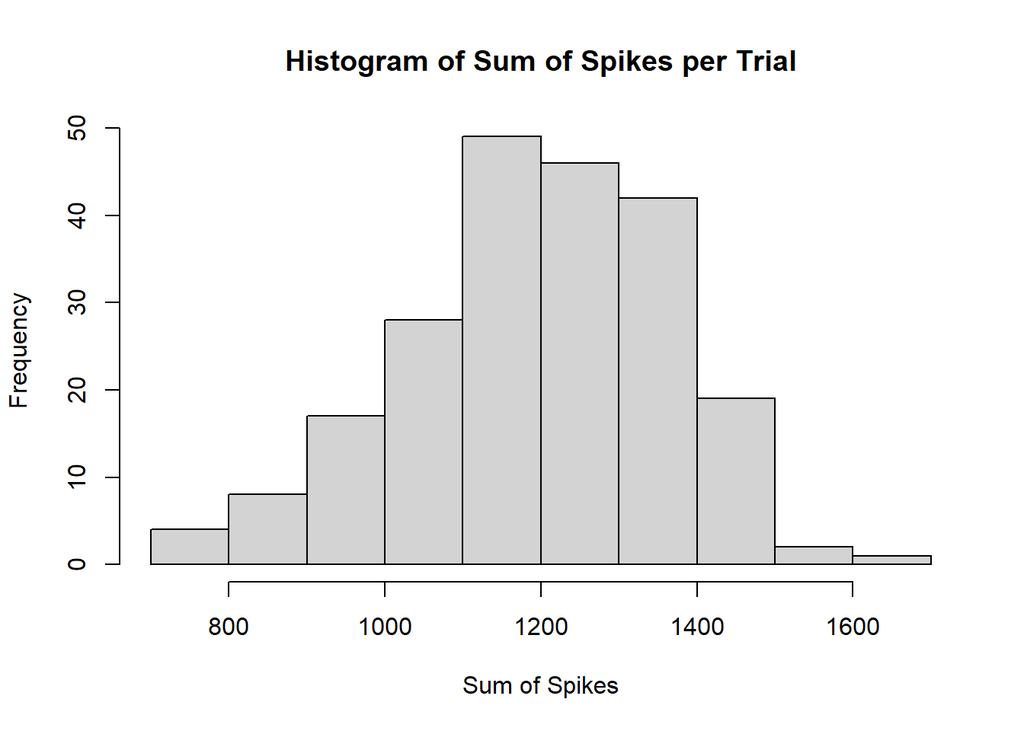

```r
# Create a new figure for the histogram


  # Create a histogram - Use 'hist' function
  hist(sum_spks, main = "Histogram of Sum of Spikes per Trial",
       xlab = "Sum of Spikes", ylab = "Frequency")
```

**(iii) Explore changes across trials**

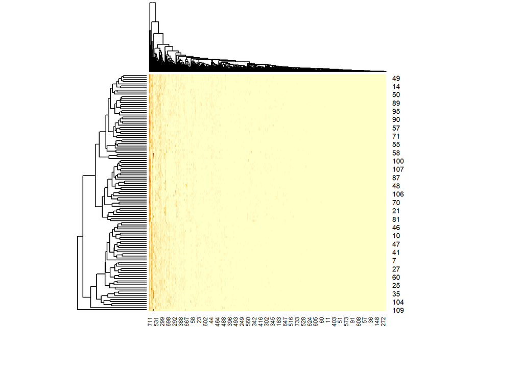

```r
library(lattice)

# Get the number of trials
num_trials <- length(session[[1]]$spks)

# Initialize lists to store results
mean_spike_counts <- list()
var_spike_counts <- list()
total_spikes_per_trial <- numeric(num_trials)

# Loop over trials
for (i in 1:num_trials) {

  # Get the spike matrix for the current trial
  spks <- session[[1]]$spks[[i]]

  # Calculate the mean spike count for each neuron
  mean_spike_count <- rowMeans(spks)
  mean_spike_counts[[i]] <- mean_spike_count

  # Calculate the variance in spike count for each neuron
  var_spike_count <- apply(spks, 1, var)
  var_spike_counts[[i]] <- var_spike_count

  # Calculate the total number of spikes in this trial
  total_spikes_per_trial[i] <- sum(spks)
}

# Convert lists to matrices for easier manipulation
mean_spike_counts <- do.call(rbind, mean_spike_counts)
var_spike_counts <- do.call(rbind, var_spike_counts)

# Now you can plot these quantities to visualize how they change across trials.
# For example, you can create a heatmap of the mean spike counts:
heatmap(mean_spike_counts)
```

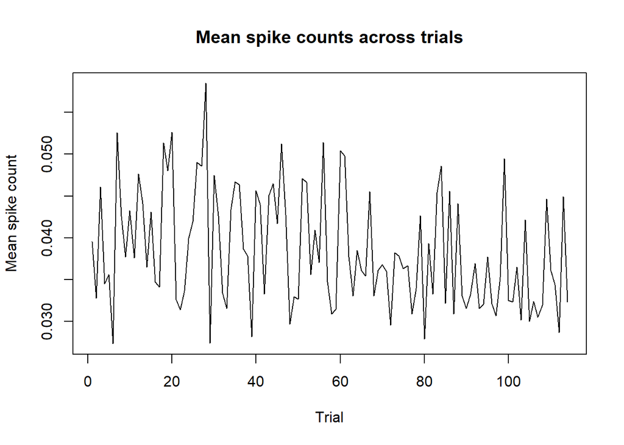

```r
# Calculate the average mean and variance of spike counts across neurons for each trial
average_mean_spike_counts <- rowMeans(mean_spike_counts)
average_var_spike_counts <- rowMeans(var_spike_counts)

# Plot average mean spike count across trials
plot(average_mean_spike_counts, type = "l", main = "Mean spike counts across trials", xlab = "Trial", ylab = "Mean spike count")
```

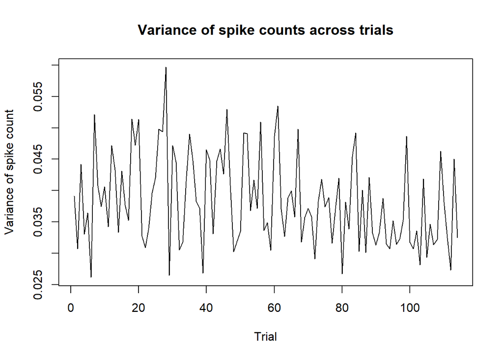

```r
# Plot average variance of spike count across trials
plot(average_var_spike_counts, type = "l", main = "Variance of spike counts across trials", xlab = "Trial", ylab = "Variance of spike count")
```

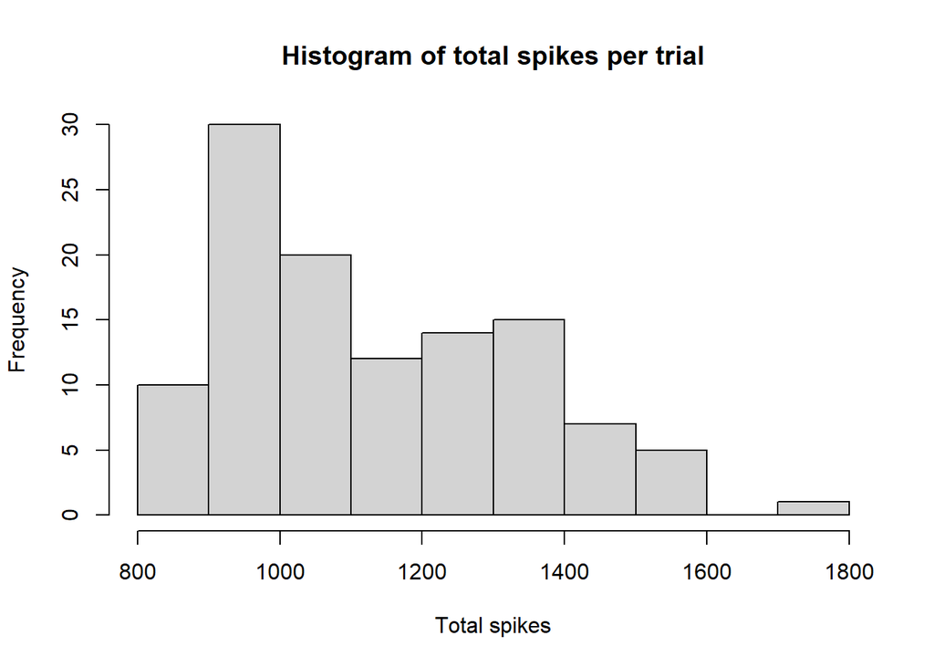

```r
hist(total_spikes_per_trial, main = "Histogram of total spikes per trial", xlab = "Total spikes", ylab = "Frequency")
```

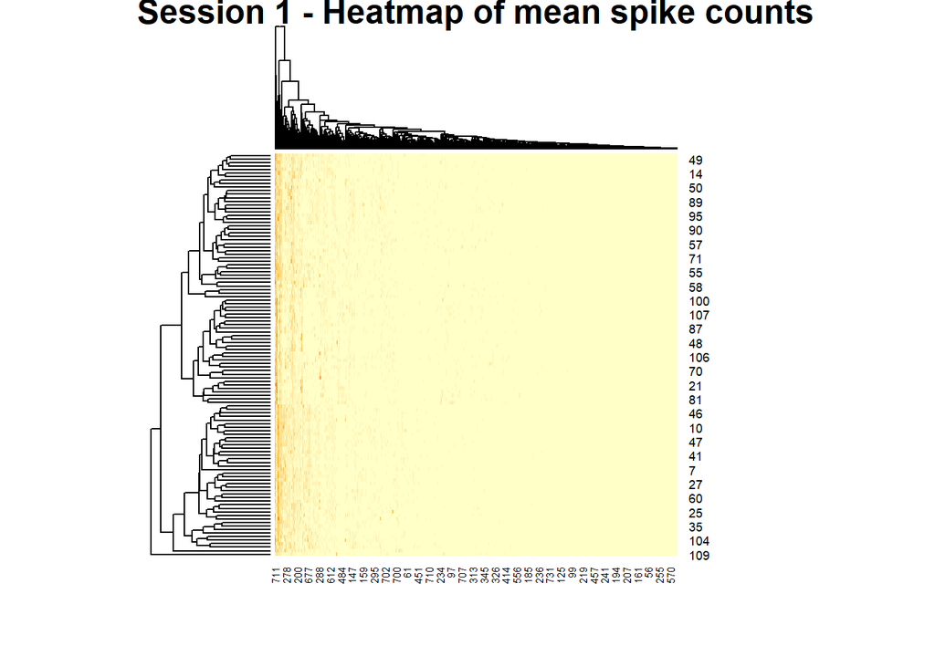

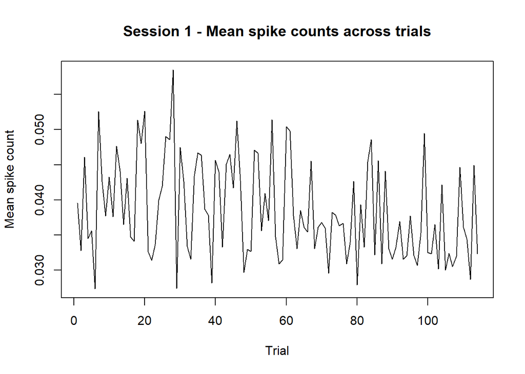

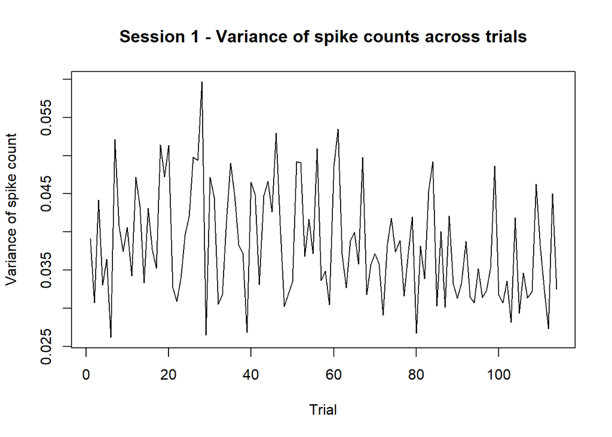

```r
# Initialize lists to store results for all sessions
all_mean_spike_counts <- list()
all_var_spike_counts <- list()
all_total_spikes_per_trial <- list()



# Loop over sessions
for (s in 1:3) {

  # Get the number of trials for the current session
  num_trials <- length(session[[s]]$spks)

  # Initialize lists to store results for the current session
  mean_spike_counts <- list()
  var_spike_counts <- list()
  total_spikes_per_trial <- numeric(num_trials)

  # Loop over trials within the current session
  for (i in 1:num_trials) {
    # Get the spike matrix for the current trial
    spks <- session[[s]]$spks[[i]]

    # Calculate the mean spike count for each neuron
    mean_spike_count <- rowMeans(spks)
    mean_spike_counts[[i]] <- mean_spike_count

    # Calculate the variance in spike count for each neuron
    var_spike_count <- apply(spks, 1, var)
    var_spike_counts[[i]] <- var_spike_count

    # Calculate the total number of spikes in this trial
    total_spikes_per_trial[i] <- sum(spks)
  }

  # Convert lists to matrices for easier manipulation
  mean_spike_counts <- do.call(rbind, mean_spike_counts)
  var_spike_counts <- do.call(rbind, var_spike_counts)

  # Store the results for the current session in the main lists
  all_mean_spike_counts[[s]] <- mean_spike_counts
  all_var_spike_counts[[s]] <- var_spike_counts
  all_total_spikes_per_trial[[s]] <- total_spikes_per_trial

  # Now, let's plot for the current session
#png(filename = paste0("session_", s, "_plots.png"), width = 800, height = 800)
  par(mfrow = c(1, 1))



  # Heatmap of mean spike counts
  heatmap(mean_spike_counts, main = paste("Session", s, "- Heatmap of mean spike counts"))
par(mfrow = c(1, 1))
  # Average mean spike counts across trials
  plot(rowMeans(mean_spike_counts), type = "l", main = paste("Session", s, "- Mean spike counts across trials"), xlab = "Trial", ylab = "Mean spike count")
  par(mfrow = c(1, 1))
  # Average variance of spike counts across trials
  plot(rowMeans(var_spike_counts), type = "l", main = paste("Session", s, "- Variance of spike counts across trials"), xlab = "Trial", ylab = "Variance of spike count")
  par(mfrow = c(1, 1))
  # Histogram of total spikes per trial
  hist(total_spikes_per_trial, main = paste("Session", s, "- Histogram of total spikes per trial"), xlab = "Total spikes", ylab = "Frequency")



  dev.off()
}
```

[output not shown]

**(iv) Exploring homogeneity and heterogeneity across sessions and mice**

```r
# Step 1: Compute mean spike count for each trial in each session
mean_spike_counts_per_trial <- lapply(session, function(s) {
  sapply(s$spks, function(spks) {
    mean(rowMeans(spks))
  })
})

# Step 2: Compute mean and standard deviation of mean spike counts for each session
mean_spike_counts_per_session <- sapply(mean_spike_counts_per_trial, mean)
sd_spike_counts_per_session <- sapply(mean_spike_counts_per_trial, sd)

# Step 3: Compute overall mean and standard deviation across all sessions
overall_mean_spike_counts <- mean(mean_spike_counts_per_session)
overall_sd_spike_counts <- sd(mean_spike_counts_per_session)

print(overall_mean_spike_counts)
```

```
## [1] 0.03425054
```

```r
print(overall_sd_spike_counts)
```

```
## [1] 0.01124031
```

```r
# Step 4: Compute Coefficient of Variation (CV) for each session
cv_per_session <- sd_spike_counts_per_session / mean_spike_counts_per_session
print(cv_per_session)
```

```
##  [1] 0.18113141 0.13663314 0.10963243 0.18008238 0.17517478 0.18187496
##  [7] 0.20286127 0.24207711 0.18018159 0.14881045 0.36379641 0.11769407
## [13] 0.07378262 0.16391834 0.12668922 0.19027432 0.15915714 0.14066993
```

```r
# Step 5: Compute overall Coefficient of Variation (CV)
overall_cv <- overall_sd_spike_counts / overall_mean_spike_counts

# Print the overall CV
print(overall_cv)
```

```
## [1] 0.3281791
```

To explore homogeneity and heterogeneity across sessions and mice, we choose to calculate the coefficient of variation (CV), which is the ratio of the standard deviation to the mean. The CV, in this context, is a measure of the variability in spike counts relative to the average spike count. We calculate both CV for each session as well as the overall CV. A lower CV suggests more homogeneity in spike counts across sessions due to lower variability. Given that for each session, as well as the overall CV, we have relatively lower values, we can conclude that there is more homogeneity across sessions and mice.

**Data integration**

**(i) Extracting shared patterns across sessions**

```r
# Load required libraries
library(cluster)

# Calculate mean firing rate for each session
mean_firing_rate <- lapply(session, function(s) {
  sapply(s$spks, function(spks) {
    mean(spks)
  })
})

# Concatenate mean firing rate data from all sessions

# Combine the individual matrices of mean firing rates into a single matrix
all_spks <- do.call(cbind, mean_firing_rate)
```

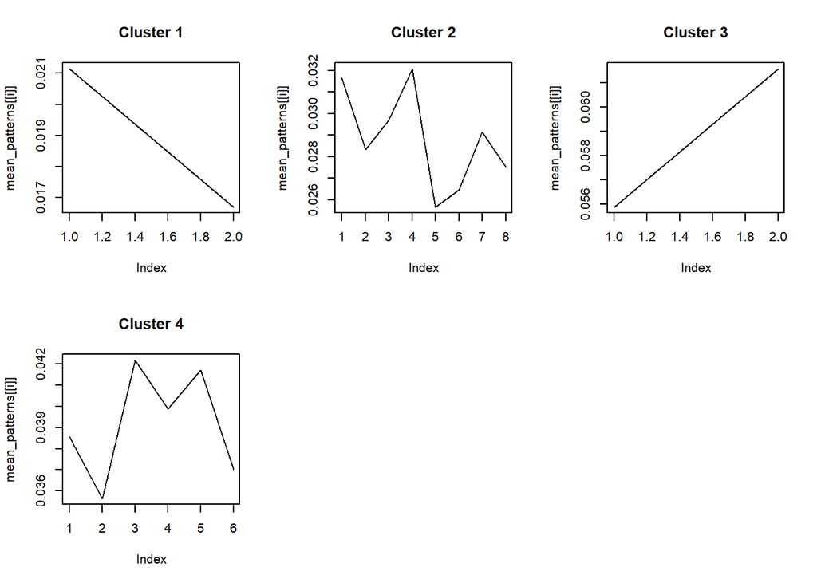

```r
# Transpose the matrix (flipping the rows and columns), as kmeans expects samples (neurons) as rows
all_spks <- t(all_spks)

# Perform k-means clustering
set.seed(200)  # for reproducibility
clust <- kmeans(all_spks, centers = 4)  # change '5' to your desired number of clusters

# Calculate mean activity pattern for each cluster
mean_patterns <- tapply(1:nrow(all_spks), clust$cluster, function(indices) {
  rowMeans(all_spks[indices, , drop = FALSE])
})

# Visualize mean patterns
par(mfrow = c(2, 3))  # change to fit your number of clusters
for (i in 1:length(mean_patterns)) {
  plot(mean_patterns[[i]], type = 'l', main = paste('Cluster', i))
}
# Standard deviation of Cluster 2
sd_cluster2 <- sd(c(0.03164665, 0.02833649, 0.02968839, 0.03208933, 0.02566012, 0.02646818, 0.02915533, 0.02752376))

# Standard deviation of Cluster 4
sd_cluster4 <- sd(c(0.03855913, 0.03563281, 0.04218341, 0.03986596, 0.04169928, 0.03700534))
```

Here, we use k-means clustering to parition data into clusters based on similarity.

The cluster 1 plot exhibits a negative linear relationship as the pattern of mean firing rates decreases from 0.02115482 to 0.01668102. This indicates that the mean firing rate from various sessions is decreasing in this cluster. Also, because of the negative linear relationship, there is a decreasing correlation between the neurons in this cluster.

The cluster 2 plot exhibits a fluctuating pattern, as shown by the values in the pasted output below.

The cluster 3 plot exhibits a positive linear relationship as the pattern of mean firing rates increases from 0.05588468 to 0.06157735. This indicates that the mean firing rate from various sessions is increasing in this cluster. Also, because of the positive linear relationship, there is a increasing correlation between the neurons in this cluster.

The cluster 4 plot exhibits another fluctuating pattern for the mean firing rates, similar to that of the cluster 2 plot. However, cluster 4 has a slightly higher standard deviation than cluster 2 (0.002589671 > 0.002298289).

> mean_patterns[[1]] [1] 0.02115482 0.01668102 mean_patterns[[2]] [1] 0.03164665 0.02833649 0.02968839 0.03208933 0.02566012 0.02646818 0.02915533 0.02752376 mean_patterns[[3]] [1] 0.05588468 0.06157735 mean_patterns[[4]] [1] 0.03855913 0.03563281 0.04218341 0.03986596 0.04169928 0.03700534

**(ii) Addressing the differences between sessions**

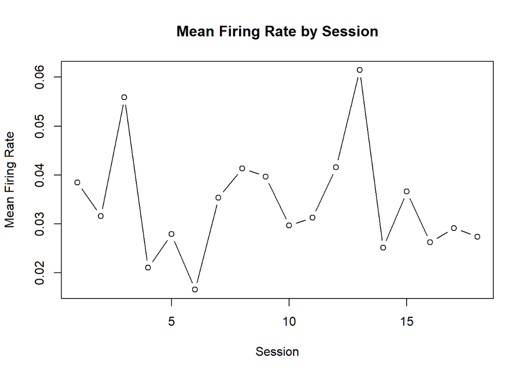

```r
# Calculate mean firing rate for each session
mean_firing_rates <- sapply(session, function(s) {
  mean_rate <- mean(unlist(sapply(s$spks, function(spks) { mean(spks) })))
  return(mean_rate)
})

# Plot mean firing rate for each session
plot(mean_firing_rates, type = "b", main = "Mean Firing Rate by Session", xlab = "Session", ylab = "Mean Firing Rate")
```

There are multiple ways to address the differences between sessions, with one way being to compare statistical differences specifically. The above code, which plots the changes in mean firing rate across the sessions, accomplishes this.

Past completed parts, such as the coefficient of variation and the sum of spiking neurons across sessions, also already address the differences between sessions.

**(iii) Enhancing the prediction performance**

```r
library(lme4)
# Fit the model
# Here, 'outcome' is your dependent variable, 'predictor' is an independent variable,
# and 'session' is your grouping variable (i.e., the variable that defines the groups across
# which you want to share information).
# Convert your list of sessions into a data frame
df <- do.call(rbind, lapply(seq_along(session), function(i) {
  data.frame(
    session = paste("Session", i),  # create session names
    mean_rate = sapply(session[[i]]$spks, mean)
  )
}))

# Now you can fit the model
model <- lmer(mean_rate ~ 1 + (1|session), data = df)

# Check the summary of the model
summary(model)
```

```
## Linear mixed model fit by REML ['lmerMod']
## Formula: mean_rate ~ 1 + (1 | session)
##    Data: df
##
## REML criterion at convergence: -37415.4
##
## Scaled residuals:
##     Min      1Q  Median      3Q     Max
## -3.1669 -0.6534 -0.0246  0.6208  4.4792
##
## Random effects:
##  Groups   Name        Variance  Std.Dev.
##  session  (Intercept) 1.262e-04 0.011234
##  Residual             3.615e-05 0.006013
## Number of obs: 5081, groups:  session, 18
##
## Fixed effects:
##             Estimate Std. Error t value
## (Intercept) 0.034250   0.002649   12.93
```

To enhance the prediction performance, we use mixed-effects modeling to enable borrowing of information across sessions. This is an application of hierarchical modeling, where we share information across different levels of a hierarchy - in this case, the sessions. We treat the mean firing rate as the dependent variable and include a random intercept for each session, allowing for variability between sessions while also capturing their shared structure.

In the previous steps, we evaluated the statistical differences across sessions using measures like the mean firing rate. Now, with hierarchical modeling, we are leveraging the similarities across sessions. By considering both these similarities and differences, we aim to build a more robust and accurate prediction model.

**Predictive Modeling**

```r
# mean firing rate
mean_firing_rate <- lapply(session, function(s) {
  sapply(s$spks, function(spks) {
    mean(spks)
  })
})

# convert numeric feedback to factor with levels "Positive" and "Negative"
data <- data.frame(
  mean_rate = unlist(mean_firing_rate),
  feedback = factor(ifelse(unlist(sapply(session, function(s) s$feedback)) == 1, "Positive", "Negative")),
  session_id = rep(1:length(session), sapply(session, function(s) length(s$spks)))  # assuming each 'spks' list has the same length
)

# prepare training data
set.seed(200)
all_indices <- 1:nrow(data)

# randomly select 100 trials from Session 1 and Session 18 respectively
test_indices_1 <- sample(which(data$session_id == 1), 100)
test_indices_18 <- sample(which(data$session_id == 18), 100)
test_indices <- c(test_indices_1, test_indices_18)

train_indices <- all_indices[!all_indices %in% test_indices]

train_data <- data[train_indices, ]

# fit the model
model <- glm(feedback ~ mean_rate, family = binomial, data = train_data)

# prepare validation data
valid_data_1 <- data[test_indices_1, ]
valid_data_18 <- data[test_indices_18, ]

# predict on validation data from Session 1
pred_1 <- predict(model, newdata = valid_data_1, type = "response")
pred_class_1 <- ifelse(pred_1 > 0.5, "Positive", "Negative")
accuracy_1 <- sum(pred_class_1 == valid_data_1$feedback) / length(valid_data_1$feedback)

# predict on validation data from Session 18
pred_18 <- predict(model, newdata = valid_data_18, type = "response")
pred_class_18 <- ifelse(pred_18 > 0.5, "Positive", "Negative")
accuracy_18 <- sum(pred_class_18 == valid_data_18$feedback) / length(valid_data_18$feedback)

# print the accuracies
print(paste0("Accuracy for Session 1: ", accuracy_1))
```

```
## [1] "Accuracy for Session 1: 0.6"
```

```r
print(paste0("Accuracy for Session 18: ", accuracy_18))
```

```
## [1] "Accuracy for Session 18: 0.78"
```

In the above code chunk, we build a logistic prediction model using the glm() function to predict feedback types among mice.I first need to train my model to predict feedback types, so I use the data from all sessions to train the data and specifically train the data to distinguish between a positive feedback type of 1 or a negative feedback type of anything else. Here, I randomly select 100 trials from session 1 and session 18 as my testing data. I then fit the model with the mean_rate variable (related to mean firing rate) and use the glm function with family = “binomial to make my logistic prediction model. I finish the code by calculating the accuracies for the respective sessions.

**Predictive performance on the test sets**

```r
# Model already trained, just feed the test data

mean_firing_rate_612 <- lapply(session612, function(s) {
  sapply(s$spks, function(spks) {
    mean(spks)
  })
})


# New test data convert numeric feedback to factor with levels "Positive" and "Negative"
data612 <- data.frame(
  mean_rate = unlist(mean_firing_rate_612),
  feedback = factor(ifelse(unlist(sapply(session612, function(s) s$feedback)) == 1, "Positive", "Negative")),
  session_id = rep(1:length(session612), sapply(session612, function(s) length(s$spks)))  # assuming each 'spks' list has the same length
)

test_indices_1 <- sample(which(data612$session_id == 1), 100)
test_indices_18 <- sample(which(data612$session_id == 2), 100)
test_indices <- c(test_indices_1, test_indices_18)

# prepare validation data
valid_data_1 <- data612[test_indices_1, ]
valid_data_18 <- data612[test_indices_18, ]

# predict on validation data from Session 1
pred_1 <- predict(model, newdata = valid_data_1, type = "response")
pred_class_1 <- ifelse(pred_1 > 0.5, "Positive", "Negative")
accuracy_1 <- sum(pred_class_1 == valid_data_1$feedback) / length(valid_data_1$feedback)

# predict on validation data from Session 18
pred_18 <- predict(model, newdata = valid_data_18, type = "response")
pred_class_18 <- ifelse(pred_18 > 0.5, "Positive", "Negative")
accuracy_18 <- sum(pred_class_18 == valid_data_18$feedback) / length(valid_data_18$feedback)

# print the accuracies
print(paste0("Accuracy for Session 1 (New test data): ", accuracy_1))
```

```
## [1] "Accuracy for Session 1 (New test data): 0.72"
```

```r
print(paste0("Accuracy for Session 18 (New test data): ", accuracy_18))
```

```
## [1] "Accuracy for Session 18 (New test data): 0.73"
```

In the above code chunk, I conducted the test with the same prediction model, but I used the data specifically from the given test files stored under the “session612” variable. This code, in comparison to the original prediction code one code chunk above, is different in the data it is testing with, and also in the fact that it does not include the code for training the data. I already trained the model by using the data I had randomly sampled originally in “predictive modeling” section, and only used the given test sets in this code to test the data. Everything else in the code was the same as previously.

**Discussion**

Based on the results of our report, we conclude that our prediction model does a fairly good job of predicting the feedback types of the each trial in the respective sessions given our accuracy rates of 0.72 for session 1 and .73 for session 18 with the given test data. The accuracy rates of .60 and .78 from my randomly sampled data also supports this conclusion. The accuracies for the prediction with the given test sets may closer to each other because the given test data may be more representative of the general consistencies or patterns within the data that were extracted throughout my code, while the data I had originally sampled the first time I tested the model may have been a bit less representative. However, I still obtained accuracies in a reasonably high range of 60-80% for both sessions with both instances of testing the prediction model, which points to the consistency and effectiveness of the model.

We can attribute the success of our model to us having taken the appropriate steps throughout the project to ensure the predictive model would be effective in the end.

Tracing back to the start of the project, performing exploratory analysis by comparing the data across sessions made it clear that we should use the mean firing rates as the main variable for our predictive model and hence integrate our data using that variable. The computation of the overall coefficient of variation ( relatively low value of .32) was especially important as it proved of homogeneity in mean firing rates across trials, which indicated that the mean firing rates would be an appropriate variable to proceed with for the data integration step.

Integrating our data was helpful in building our predictive model because we combined data across sessions in a way where both similarities and differences were accounted for.

Given the nature of how we integrated the data, we could confidently move on with forming our prediction model because we knew we had combined the data in a way where all major aspects of the data across sessions where accounted for and hence the data was representative enough to have predictions made of off it.

In context of real-world applications, this report was able to demonstrate how data science, which incorporates both statistical methods as well programming, is capable of solving quite complex problems. In this specific problem, we were initially tasked with being building an accurate prediction model while being given a vast amount of challenging data. However, after applying a series of data science tactics to explore, integrate, and model our data, we now have a prediction model that be used to make real conclusions about how neural activity works. In essence, this report exhibits the primary purpose of data science as an interdisciplinary field: to extract as much meaningful information as possible out of a given set of data.

**Acknowledgements**

Throughout this report, chatGPT was utilized in order to understand different methods for answering the questions, and code was used from chatGPT for most of my questions as well.

For the Abstract and Introduction sections specifcally, I was able to write or provide information on everything myself based on my knowledge gained from studying the experiment’s details and also my knowledge of data structures in R.

For the Exploratory Analysis section, I utilized code from chatGPT to loop the data and make plots of the sum of spikes for each session. I then wrote the histogram code myself to give a summary of the data. For the other portions, I also consulted chatGPT, but needed to review the concepts and understand/verify the codes to analyze or describe what was occuring.

For the Data Integration section, although I used code from chatGPT, I was able to verify that everything was correct because I had used technniques we have already covered in class, such as k-means clustering.

For the predictive modeling section and the predictive modeling with test sets section, I incorporated code from chatGPT, but was able to verify everything was correct and understand the code well because the concepts applied were already covered in the class and practiced in homework 4.

Overall, I utilized chatGPT to write most of the code for this report, but I was able to understand the code both by typing it out and also by consulting previous assignments where similar topics were employed as well as reviewing the concepts from the class notes/lectures.

**Appendix**

One trial of one session

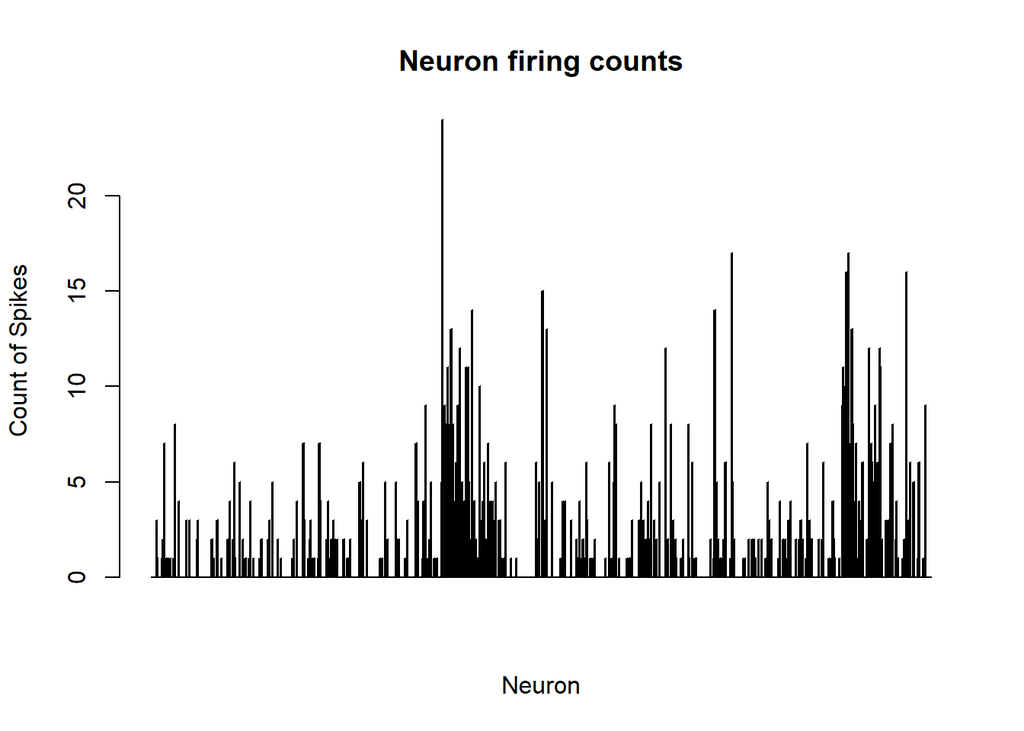

```r
spks <- session[[1]]$spks[[1]]  # extract the first (and only) 'spks' matrix



# Compute the sum of spikes for each neuron
neuron_spikes <- rowSums(spks)



# Plot the sum of spikes for each neuron
barplot(neuron_spikes, main = "Neuron firing counts", xlab = "Neuron", ylab = "Count of Spikes")
```

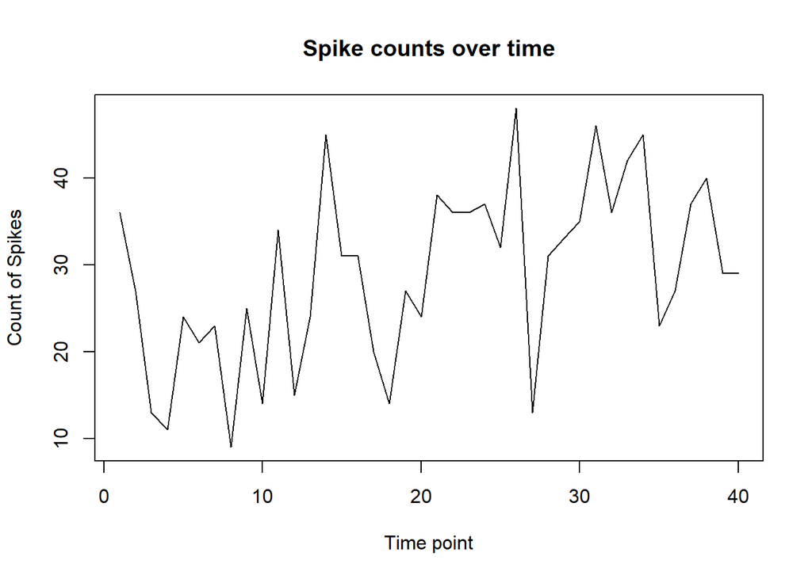

```r
# Compute the sum of spikes for each time point
time_spikes <- colSums(spks)



# Plot the sum of spikes at each time point
plot(time_spikes, type = "l", main = "Spike counts over time", xlab = "Time point", ylab = "Count of Spikes")
```

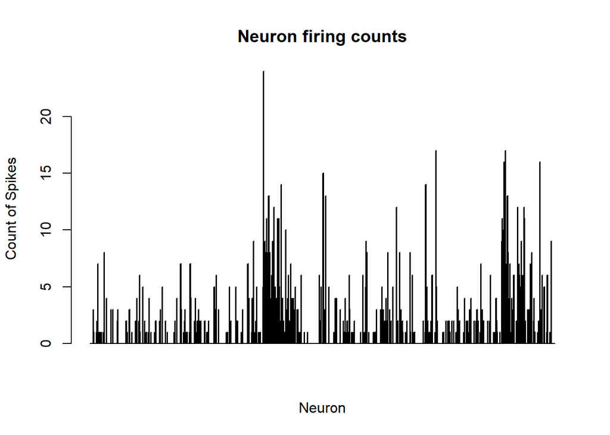

```r
#Next Trial

spks1 <- session[[1]]$spks[[75]]  # extract the first (and only) 'spks' matrix



# Compute the sum of spikes for each neuron
neuron_spikes <- rowSums(spks)

# Plot the sum of spikes for each neuron
barplot(neuron_spikes, main = "Neuron firing counts", xlab = "Neuron", ylab = "Count of Spikes")
```

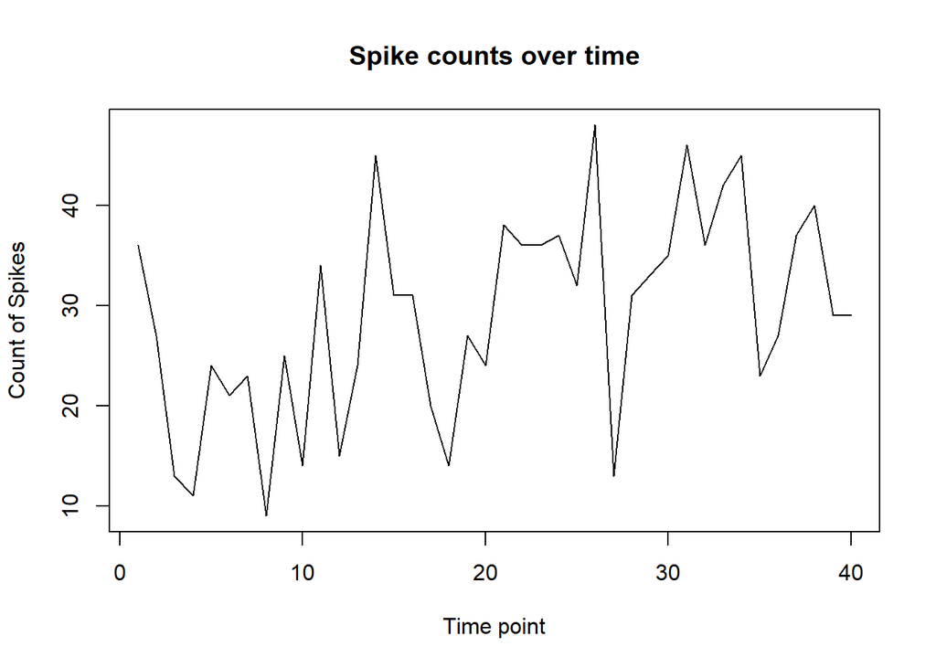

```r
# Compute the sum of spikes for each time point
time_spikes <- colSums(spks)

# Plot the sum of spikes at each time point
plot(time_spikes, type = "l", main = "Spike counts over time", xlab = "Time point", ylab = "Count of Spikes")
```